# Proyecto 1

Ruth Nohemy Ardón Lechuga, 999006711

01 agosto 2022

### Conociendo los datos

- Cargue el paquete tidyverse.
- Lea el archivo deaths_handwashing.csv usando read_csv y asígnelo a la variable yearly.
- Imprima la variable yearly.

```r
library(tidyverse)
yearly <- read_csv("./data/deaths_handwashing.csv",show_col_types = FALSE)
print(yearly)
```

| year | births | deaths | clinic |
| --- | --- | --- | --- |
| 1841 | 3036 | 237 | clinic 1 |
| 1842 | 3287 | 518 | clinic 1 |
| 1843 | 3060 | 274 | clinic 1 |
| 1844 | 3157 | 260 | clinic 1 |
| 1845 | 3492 | 241 | clinic 1 |
| 1846 | 4010 | 459 | clinic 1 |
| 1841 | 2442 | 86 | clinic 2 |
| 1842 | 2659 | 202 | clinic 2 |
| 1843 | 2739 | 164 | clinic 2 |
| 1844 | 2956 | 68 | clinic 2 |

[output cut: 2 more lines]

### El alarmante número de muertes

La tabla anterior muestra el número de mujeres que dieron a luz durante los años 1841 a 1846 en una ciudad al noreste de Austria, en dos clínicas en particular. Notará que dar a luz era muy peligroso; un número alarmante de mujeres murió como resultado del parto. Vemos esto con mayor claridad si observamos la proporción de muertes con respecto al número de mujeres que dieron a luz

- Use mutate para agregar la columna proportion_deaths a yearly, esta nueva columna se calculará como la proporción de muertes por número de nacimientos
- Imprima yearly.

```r
yearly <- mutate(yearly, proportion_deaths = deaths/births)
print(yearly)
```

| year | births | deaths | clinic | proportion_deaths |
| --- | --- | --- | --- | --- |
| 1841 | 3036 | 237 | clinic 1 | 0.07806324 |
| 1842 | 3287 | 518 | clinic 1 | 0.15759051 |
| 1843 | 3060 | 274 | clinic 1 | 0.08954248 |
| 1844 | 3157 | 260 | clinic 1 | 0.08235667 |
| 1845 | 3492 | 241 | clinic 1 | 0.06901489 |
| 1846 | 4010 | 459 | clinic 1 | 0.11446384 |
| 1841 | 2442 | 86 | clinic 2 | 0.03521704 |
| 1842 | 2659 | 202 | clinic 2 | 0.07596841 |
| 1843 | 2739 | 164 | clinic 2 | 0.05987587 |
| 1844 | 2956 | 68 | clinic 2 | 0.02300406 |

[output cut: 2 more lines]

### Muerte en las clínicas

- Utilice ggplot para hacer una gráfica lineal de proportion_deaths por año (columna year) con una línea por clínica.
- Las líneas deben tener colores distintos

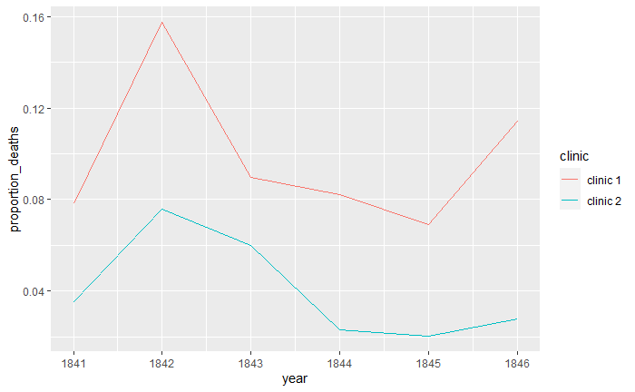

```r
ggplot(yearly, aes(x=year,y=proportion_deaths, group=clinic, color=clinic))+geom_line()
```

### Comienza el lavado de manos

¿Por qué la proporción de muertes es mucho más alta en la Clínica 1? La única diferencia en ambas clínicas era que muchos estudiantes de medicina trabajaban en la Clínica 1, mientras que en la Clínica 2 no había tantos. Otro dato interesante es que los médicos que atendían partos solo se encargaban de esa función, mientras que los estudiantes también pasaban tiempo en las salas de autopsias examinando cadáveres.

Se empezó a sospechar que algo en los cadáveres, propagado de las manos de los estudiantes de medicina, causaba la enfermedad. Entonces, en un intento desesperado por detener las altas tasas de mortalidad, se decretó: ¡Lávese las manos en todo momento!

- Cargue los datos mensuales de la Clínica 1 para ver si el lavado de manos tuvo algún efecto, para esto lea el archivo deaths_clinic_1.csv y asígnelo a la variable monthly.
- Agregue la columna proportion_deaths a monthly, esta nueva columna se calculará como la proporción de muertes por número de nacimientos
- Imprima las primeras filas de monthly usando la función head().

```r
monthly <- read_csv("./data/deaths_clinic_1.csv",show_col_types = FALSE)
monthly <- mutate(monthly, proportion_deaths = deaths/births)
print(head(monthly,n=10))
```

| date | births | deaths | proportion_deaths |
| --- | --- | --- | --- |
| 1841-01-01 | 254 | 37 | 0.145669291 |
| 1841-02-01 | 239 | 18 | 0.075313808 |
| 1841-03-01 | 277 | 12 | 0.043321300 |
| 1841-04-01 | 255 | 4 | 0.015686275 |
| 1841-05-01 | 255 | 2 | 0.007843137 |
| 1841-06-01 | 200 | 10 | 0.050000000 |
| 1841-07-01 | 190 | 16 | 0.084210526 |
| 1841-08-01 | 222 | 3 | 0.013513514 |
| 1841-09-01 | 213 | 4 | 0.018779343 |
| 1841-10-01 | 236 | 26 | 0.110169492 |

### El efecto del lavado de manos

Con los datos cargados, ahora podemos ver la proporción de muertes a lo largo del tiempo.

- Haga una gráfica lineal de proportion_deaths por fecha para el data frame monthly usando ggplot.
- Utilice la función labs para dar al eje x y al eje y una estética a las etiquetas.
- Use group_by y summarise para encontrar la media por año y guárdelo en el dataset death_by_year.
- Utilice el conjunto de datos death_by_year para crear un gráfico de barras que muestre la media en cada año.

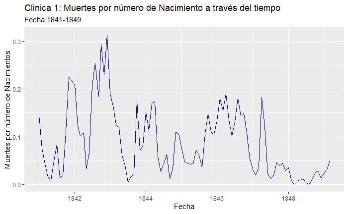

```r
graph <- ggplot(monthly, aes(x=date,y=proportion_deaths,color="Clínica 1"))+geom_line(colour="#000099")

graph + labs(title="Clinica 1: Muertes por número de Nacimiento a través del tiempo",
            subtitle = "Fecha 1841-1849",
            x="Fecha",
            y="Muertes por número de Nacimientos")
```

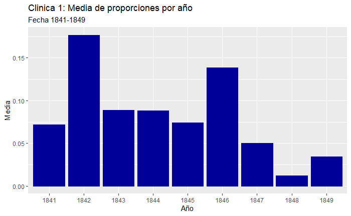

```r
death_by_year <- monthly%>%group_by(format(as.Date(date, format="%d/%m/%Y"),"%Y"))%>%summarise(Mean = mean(proportion_deaths))
names(death_by_year)[1] = "Year"

mean_graph <- ggplot(death_by_year, aes(x=Year,y=Mean))+geom_bar(stat='identity',colour="#000099", fill = "#000099")
mean_graph + labs(title="Clinica 1: Media de proporciones por año",
            subtitle = "Fecha 1841-1849",
            x="Año",
            y="Media")
```

### Los resultados del lavado de manos

A partir del año 1847 la proporción de muertes se reduce drásticamente y, sí, fue entonces cuando se hizo obligatorio el lavado de manos.

El efecto del lavado de manos se hace aún más claro si lo resaltamos en el gráfico.

- Agregue una columna TRUE/FALSE a monthly llamado handwashing_started, que será TRUE a partir del año en que se impuso el lavado de manos.
- Haga una gráfica lineal de proportion_deaths por fecha para el data frame monthly usando ggplot. Haga que el color de la línea dependa de handwashing_started.
- Utilice la función labs para dar al eje x y al eje y una estética a las etiquetas.

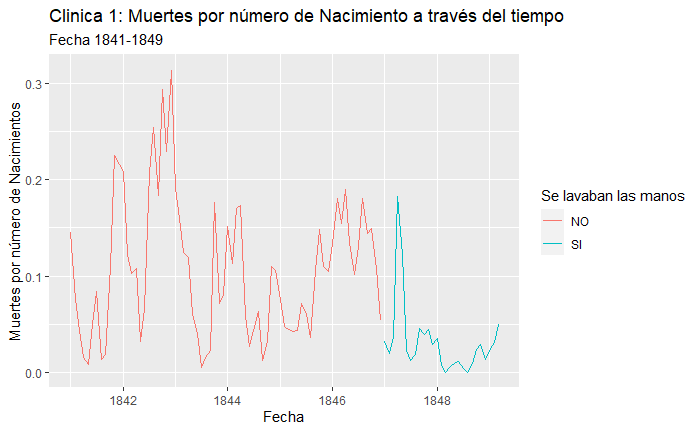

```r
monthly <- mutate(monthly, handwashing_started = format(as.Date(date, format="%d/%m/%Y"),"%Y")>=1847)
graph_handwashing_started <- ggplot(monthly, aes(x=date,y=proportion_deaths,color=handwashing_started))+geom_line()

graph_handwashing_started + labs(title="Clinica 1: Muertes por número de Nacimiento a través del tiempo",
            subtitle = "Fecha 1841-1849",
            x="Fecha",
            y="Muertes por número de Nacimientos") + scale_color_discrete(name = "Se lavaban las manos", labels = c("NO", "SI"))
```

### ¿Más lavado de manos, menos muertes?

Nuevamente, las estadísticas demuestran que lavarse las manos tuvo un efecto enorme. ¿Cuánto redujo la proporción mensual de muertes en promedio?

- Utilice group_by y summarise para calcular el promedio de proportion_deaths antes y después de que se impusiera el lavado de manos.
- Asigne el resultado en la variable month_summary e imprímala.

```r
month_summary <- monthly%>%group_by(handwashing_started)%>%summarise(Mean = mean(proportion_deaths))
print(month_summary)
```

| handwashing_started | Mean |
| --- | --- |
| FALSE | 0.10691840 |
| TRUE | 0.03172764 |

### Análisis estadístico de los datos de lavado de manos

Utilice la función t.test para calcular un intervalo de confianza del 95%. Los dos grupos que tenemos son proporción mensual de muertes antes y después de que comenzara el lavado de manos “proportion_deaths” y “handwashing_started”.

```r
monthly_true <- (monthly%>%filter(handwashing_started))$proportion_deaths
monthly_false <- (monthly%>%filter(!handwashing_started))$proportion_deaths

t.test(monthly_true,monthly_false)
```

```
    Welch Two Sample t-test

data:  monthly_true and monthly_false
t = -6.7105, df = 84.198, p-value = 2.114e-09
alternative hypothesis: true difference in means is not equal to 0
95 percent confidence interval:
 -0.09747238 -0.05290915
sample estimates:
 mean of x  mean of y
0.03172764 0.10691840
```